# Homework 01

## Question 1 (Least squares and matrix calculations)

I generated the predictors and response using the requested seed. The design matrix has 100 rows and 6 columns (the intercept plus five predictors), and its rank is 6.

```r
set.seed(43201)
n <- 100
p <- 5
x <- matrix(rnorm(n * p), nrow = n, ncol = p)
colnames(x) <- paste0("x", seq_len(p))
X <- cbind(intercept = 1, x)
beta <- c(3, 1.4, -0.9, 0.7, 0, 1.1)
epsilon <- rnorm(n, mean = 0, sd = 0.7)
y <- drop(X %*% beta + epsilon)

# lm.fit uses QR decomposition rather than explicitly inverting X'X.
fit <- lm.fit(X, y)
beta_hat <- fit$coefficients
fitted_values <- drop(X %*% beta_hat)
residuals <- y - fitted_values

print(dim(X))
cat("rank:", qr(X)$rank, "\n")
print(round(cbind(generated = beta, estimated = beta_hat), 4))
```

```
[1] 100   6
rank: 6
          generated estimated
intercept       3.0    3.0063
x1              1.4    1.4172
x2             -0.9   -0.8883
x3              0.7    0.7953
x4              0.0    0.0484
x5              1.1    1.1319
```

The fitted values are `X %*% beta_hat`, and the residuals are `y - fitted_values`. The training RMSE is 0.6764.

```r
training_rmse <- sqrt(mean(residuals^2))
normal_equation_error <- max(abs(crossprod(X, residuals)))
cat("training RMSE:", training_rmse, "\n")
cat("||X' residuals||_infinity:", normal_equation_error, "\n")
```

```
training RMSE: 0.6763696
||X' residuals||_infinity: 5.878631e-14
```

The reported infinity norm is approximately $5.9\times 10^{-14}$. Least squares makes the residual orthogonal to every column of the design matrix, so $\mathbf{X}^{\mathsf T}\mathbf{r}=0$ mathematically. The small nonzero value is floating-point roundoff. In particular, orthogonality to the intercept means the residuals also sum to approximately zero.

## Question 2 (Gaussian likelihood for linear regression)

### a.

For fixed $\sigma^2$, the first term of the log-likelihood is constant in $\boldsymbol\beta$. The remaining term is a negative constant times the residual sum of squares. Therefore, maximizing the likelihood is the same optimization problem as minimizing the residual sum of squares. Thus the maximum-likelihood estimate of $\boldsymbol\beta$ is the least-squares estimate `beta_hat` from Question 1.

### b.

Writing $v=\sigma^2$ and $\operatorname{RSS}(\boldsymbol\beta)=\|\mathbf{y}-\mathbf{X}\boldsymbol\beta\|_2^2$, the derivative is

$$\frac{\partial \ell}{\partial v}
=-\frac{n}{2v}+\frac{\operatorname{RSS}(\boldsymbol\beta)}{2v^2}.$$

Setting this equal to zero gives

$$\widehat{\sigma}^2_{\mathrm{MLE}}=
\frac{\operatorname{RSS}(\widehat{\boldsymbol\beta})}{n}.$$

Here the residual sum of squares is 45.7476, so the MLE is 0.4575. The usual unbiased estimate is

$$\widehat{\sigma}^2_{\mathrm{unbiased}}=
\frac{\operatorname{RSS}}{n-6}=0.4867.$$

The denominators differ because the likelihood estimator divides by the number of observations, while the unbiased estimator accounts for the six fitted coefficients and uses the residual degrees of freedom. Under the model, the expected residual sum of squares is $(n-6)\sigma^2$.

```r
rss <- sum(residuals^2)
sigma2_mle <- rss / n
sigma2_unbiased <- rss / (n - ncol(X))
cat("RSS:", rss, "\n")
cat("MLE variance:", sigma2_mle, "\n")
cat("Unbiased variance:", sigma2_unbiased, "\n")
```

```
RSS: 45.74759
MLE variance: 0.4574759
Unbiased variance: 0.4866765
```

### c.

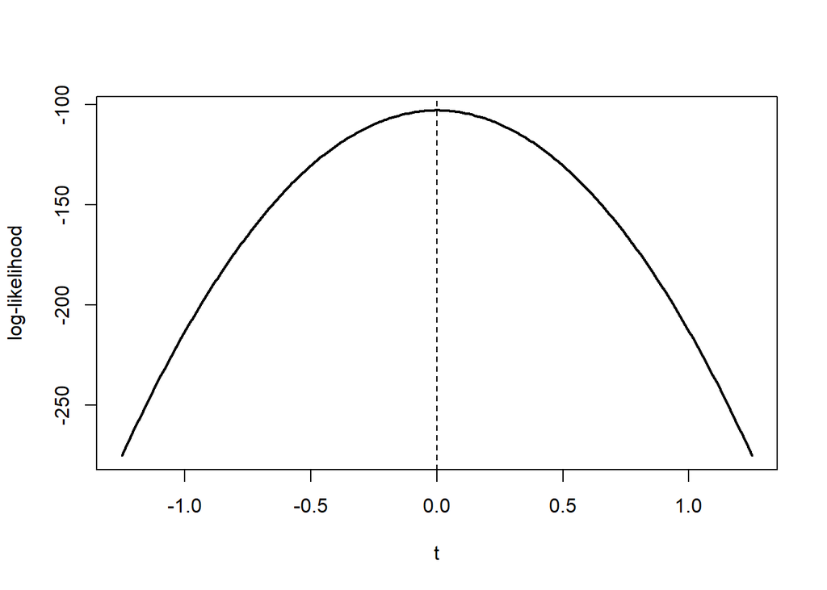

Log-likelihood profile when the x2 coefficient is perturbed.

```r
log_likelihood <- function(coef, variance) {
  error <- y - drop(X %*% coef)
  -n / 2 * log(2 * pi * variance) - sum(error^2) / (2 * variance)
}

t_grid <- seq(-1.25, 1.25, length.out = 251)
profile <- vapply(t_grid, function(t) {
  direction <- c(0, 0, 1, 0, 0, 0)
  log_likelihood(beta_hat + t * direction, sigma2_mle)
}, numeric(1))

plot(t_grid, profile, type = "l", lwd = 2,
     xlab = "t", ylab = "log-likelihood")
abline(v = 0, lty = 2)
```

```r
cat("grid value with largest log-likelihood:", t_grid[which.max(profile)], "\n")
```

```
grid value with largest log-likelihood: 0
```

The maximum on the grid occurs at $t=0$. This is the original least-squares coefficient vector. Changing only the `x2` coefficient away from its least-squares value increases the residual sum of squares, so with the variance held fixed it lowers the log-likelihood.

## Question 3 (Starting values in nonconvex optimization)

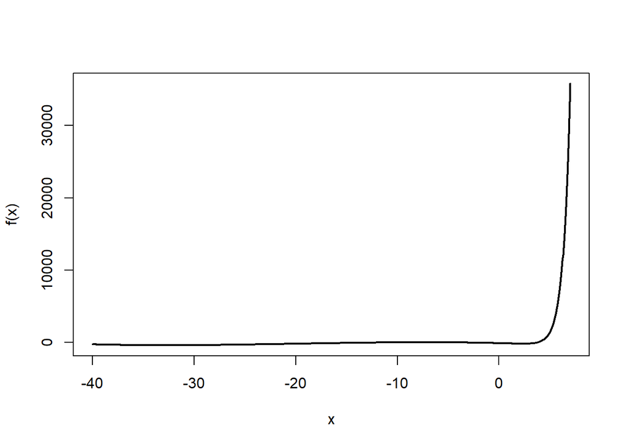

The nonconvex objective over the requested interval.

```r
objective <- function(x) exp(1.5 * x) - 3 * (x + 6)^2 - 0.05 * x^3
derivative <- function(x) 1.5 * exp(1.5 * x) - 6 * (x + 6) - 0.15 * x^2

curve(objective, from = -40, to = 7, n = 1000,
      xlab = "x", ylab = "f(x)", lwd = 2)
```

The plot has more than one valley separated by a hill, so it is not convex over the interval. The exponential term becomes dominant on the right, while the polynomial terms shape the left side. This combination creates local minima and makes the starting value relevant to a local optimizer.

```r
starts <- c(-15, 0)
for (start in starts) {
  result <- optim(start, objective, gr = derivative, method = "BFGS")
  cat("start:", start,
      " final x:", result$par,
      " final f(x):", result$value,
      " |f'(x)|:", abs(derivative(result$par)),
      " converged:", result$convergence == 0, "\n")
}
```

```
start: -15  final x: -32.64911  final f(x): -390.3858  |f'(x)|: 8.725087e-08  converged: TRUE
start: 0  final x: 2.349967  final f(x): -175.8626  |f'(x)|: 6.556057e-07  converged: TRUE
```

Starting at $-15$ gives approximately $x=-32.6491$ and $f(x)=-390.3858$, with $|f'(x)|\approx 8.7\times10^{-8}$. Starting at 0 gives approximately $x=2.3500$ and $f(x)=-175.8626$, with $|f'(x)|\approx 6.6\times10^{-7}$. Both runs report convergence, but the first run has the lower objective value.

The optimizer is local, so convergence means it found a nearby stationary minimum, not that it compared every possible point. To claim a global minimum, I would need additional evidence such as a systematic multi-start search over the interval, a dense evaluation of the objective, and an argument that no lower region was missed.

## Question 4 (Nearly collinear predictors)

```r
set.seed(43202)
u <- rnorm(n)
x6 <- x[, 1] + 1e-4 * u
X_plus <- cbind(X, x6 = x6)
y_star <- y + 1e-3 * u

fit_original <- lm.fit(X, y)
fit_augmented <- lm.fit(X_plus, y)
fit_perturbed <- lm.fit(X_plus, y_star)

rmse <- function(actual, predicted) sqrt(mean((actual - predicted)^2))
cat("condition number X:", kappa(X, exact = TRUE), "\n")
cat("condition number X_plus:", kappa(X_plus, exact = TRUE), "\n")
cat("RMSE with X:", rmse(y, X %*% fit_original$coefficients), "\n")
cat("RMSE with X_plus:", rmse(y, X_plus %*% fit_augmented$coefficients), "\n")
cat("x1 and x6 coefficients for y:\n")
print(fit_augmented$coefficients[c("x1", "x6")])
cat("x1 and x6 coefficient changes for y_star - y:\n")
print(fit_perturbed$coefficients[c("x1", "x6")] -
      fit_augmented$coefficients[c("x1", "x6")])

fitted_difference <- X_plus %*% fit_perturbed$coefficients -
  X_plus %*% fit_augmented$coefficients
cat("fitted-value RMS difference:", sqrt(mean(fitted_difference^2)), "\n")
cat("maximum fitted-value difference:", max(abs(fitted_difference)), "\n")
```

```
condition number X: 1.524914
condition number X_plus: 20209.2
RMSE with X: 0.6763696
RMSE with X_plus: 0.6754668
x1 and x6 coefficients for y:
       x1        x6
 351.6766 -350.2588
x1 and x6 coefficient changes for y_star - y:
 x1  x6
-10  10
fitted-value RMS difference: 0.001015879
maximum fitted-value difference: 0.002572675
```

For $\mathbf{X}$, the condition number is about 1.525 and the training RMSE is 0.6764. For $\mathbf{X}_+$, the condition number rises to about 20,209 and the training RMSE for fitting $\mathbf{y}$ is 0.6755. The augmented coefficients of `x1` and `x6` are approximately 351.6766 and -350.2588. After replacing $\mathbf y$ with $\mathbf y^\star$, those coefficients change by -10 and +10, respectively.

The fitted vectors have RMS difference about 0.001016 and maximum absolute difference about 0.002573. The identity in the question says

$$\mathbf y^\star-\mathbf y=10(\mathbf x_6-\mathbf x_1).$$

Thus the response perturbation is itself almost a combination of the two nearly duplicate columns. The coefficient representation can move substantially between those columns while their combined contribution to the fitted values changes only slightly. Separate coefficient interpretations are therefore unstable when predictors are nearly collinear; the joint fitted contribution is more reliable.

## Question 5 (Data preparation and summary statistics)

```r
data <- read.csv("data/data-manipulation.csv", stringsAsFactors = FALSE)
analysis <- data[!is.na(data$response), ]
analysis$feature_sum <- analysis$x1 + analysis$x2

cat("dimensions:", paste(dim(data), collapse = " x "), "\n")
print(sapply(data, class))
cat("duplicated identifiers:", sum(duplicated(data$observation_id)), "\n")
cat("missing values by column:\n")
print(colSums(is.na(data)))

group_summary <- aggregate(cbind(response, feature_sum) ~ group,
                           data = analysis,
                           FUN = mean)
group_counts <- aggregate(response ~ group, data = analysis, FUN = length)
names(group_counts)[2] <- "observations"
print(merge(group_counts, group_summary, by = "group"))

top_three <- analysis[order(-analysis$response),
                      c("observation_id", "group", "response", "feature_sum")]
print(head(top_three, 3))

stopifnot(nrow(analysis) == sum(!is.na(data$response)))
stopifnot(!anyNA(analysis$response))
stopifnot(!anyDuplicated(analysis$observation_id))
cat("all data checks passed\n")
```

```
dimensions: 24 x 5
observation_id          group             x1             x2       response
   "character"    "character"      "numeric"      "numeric"      "numeric"
duplicated identifiers: 0
missing values by column:
observation_id          group             x1             x2       response
             0              0              0              0              3
  group observations response feature_sum
1     A            7 5.600000    3.600000
2     B            7 7.602857    4.928571
3     C            7 7.997143    6.585714
   observation_id group response feature_sum
22         obs-22     C     9.24         6.6
16         obs-16     B     9.00         5.2
14         obs-14     B     8.66         5.0
all data checks passed
```

The data has dimensions 24 by 5. The identifier and group columns are character, and the three measurement columns are numeric. There are no duplicated identifiers. The missing-value counts for `observation_id`, `group`, `x1`, `x2`, and `response` are 0, 0, 0, 0, and 3, respectively. The analysis table contains the 21 observations with recorded responses, and `feature_sum` is defined as `x1 + x2`.

The group summaries describe only those 21 observations with nonmissing responses:

| Group | Observations | Mean response | Mean feature_sum |
| --- | --- | --- | --- |
| A | 7 | 5.6000 | 3.6000 |
| B | 7 | 7.6029 | 4.9286 |
| C | 7 | 7.9971 | 6.5857 |

The three largest responses are:

| observation_id | group | response | feature_sum |
| --- | --- | --- | --- |
| obs-22 | C | 9.24 | 6.6 |
| obs-16 | B | 9.00 | 5.2 |
| obs-14 | B | 8.66 | 5.0 |

The checks confirm that the retained row count equals the number of nonmissing responses, the analysis response has no missing values, and the retained identifiers are unique.

## Question 6 (Can 39 million Fitbit records represent US adults?)

### a.

The 39 million daily records are not independent observations. Multiple records come from the same participant, so they share that person’s characteristics, routines, device, and participation history. Participants may also contribute different numbers of days because of when they enrolled, device wear time, charging or syncing habits, loss of follow-up, illness, or whether they use the device consistently. If one participant contributes twice as many recorded days as another, an average over all days gives the first participant twice the weight. That is different from the stated target, which gives each adult equal weight after forming that adult’s average.

### b.

The BYOD and WEAR medians do not show that owning a Fitbit causes people to walk more. The groups were not randomly assigned to already owning a device. BYOD participants could differ in income, health, interest in exercise, access to technology, or prior activity from people who accepted an offered device. The reported differences in race and income are evidence that the groups have different compositions. A plausible alternative is that people who already owned and used a Fitbit were more interested in monitoring activity, while the WEAR group included people recruited specifically because they did not already have a device.

### c.

Participant selection can differ from the US adult population through enrollment in All of Us, access to or interest in Fitbit devices, willingness to share data, and the two different recruitment routes. The BYOD and WEAR composition differences show that the route into the dataset matters. Recorded-day selection can also differ: days with the device worn and synced are more likely to appear than days when a participant removes it, forgets to charge it, or stops syncing. Seasonal timing and length of follow-up can differ across participants as well.

Consequently, a recorded-day average combines selection of people with selection of days within people. It can overrepresent participants who provide many days and overrepresent the types of days on which recording is more likely. That weighting does not match the target, which is the equally weighted mean of participant-specific average daily steps among US adults. A very large number of records reduces random noise conditional on the observed data, but it does not by itself remove this selection bias. The direction of the bias cannot be determined from the information given.